# TRGAted App: Multiple Variate Analysis

Nick Borcherding

6/3/2018

# Set Up

The goal of this tutorial is basic multivariate analysis using the reverse-phase protein array (RPPA) data and clinical variables available in the TRGAted application. We will start with looping across clinical variables as single covariates. Preceeding to mutlivariate analysis using categorical clinical variables.

### Load Libraries

```r
library(survMisc)
```

```r
library(ggplot2)
library(ggfortify)
library(survival)
library(survminer)
```

### Load Cancer Data

This could be any .csv file located in the TRGAted github repository.

```r
cancerType <- read.csv("~/TRGAted/BRCA.csv")
```

Preview the clinical variables available on the data frame

```r
colnames(cancerType[,2:9])
```

```
## [1] "subtype"                        "age"
## [3] "gender"                         "race"
## [5] "ajcc_pathologic_tumor_stage"    "histological_type"
## [7] "histological_grade"             "treatment_outcome_first_course"
```

Preview the survival information available on the data frame

```r
colnames(cancerType[,10:17])
```

```
## [1] "OS"       "OS.time"  "DSS"      "DSS.time" "DFI"      "DFI.time"
## [7] "PFI"      "PFI.time"
```

# Analysis

### Survival analysis looping across multiple variables

Setting the variables of interest - time, the respective survival indicator for selected time (ind), and clinical variables (covariates).

```r
#Slecting the survival and time variables of interest
time = cancerType[,"DSS.time"] #diseas-specific survival
ind = cancerType[,"DSS"]

#Selecting the clincal variables of interest
covariates <- c("subtype","ajcc_pathologic_tumor_stage", "histological_type")
```

Looping over Cox regression for each individual variable, this is a good first step before multivariate analysis that allows for better selection of clinical variables.

```r
### loop through each variable
for (i in 1:length(covariates)){
    print(covariates[i])
    print(coxph(Surv(time, ind) ~ get(covariates[i]), data=cancerType))
}
```

```
## [1] "subtype"
```

```
## Call:
## coxph(formula = Surv(time, ind) ~ get(covariates[i]), data = cancerType)
##
##                               coef exp(coef)  se(coef)     z    p
## get(covariates[i])Her2    5.31e-01  1.70e+00  4.87e-01  1.09 0.28
## get(covariates[i])LumA   -1.56e-01  8.55e-01  3.69e-01 -0.42 0.67
## get(covariates[i])LumB    2.64e-01  1.30e+00  4.09e-01  0.65 0.52
## get(covariates[i])Normal -1.70e+01  3.94e-08  3.77e+03  0.00 1.00
##
## Likelihood ratio test=6.7  on 4 df, p=0.2
## n= 670, number of events= 55
##    (203 observations deleted due to missingness)
## [1] "ajcc_pathologic_tumor_stage"
## Call:
## coxph(formula = Surv(time, ind) ~ get(covariates[i]), data = cancerType)
##
##                               coef exp(coef) se(coef)    z       p
## get(covariates[i])Stage II   0.782     2.186    0.538 1.45  0.1459
## get(covariates[i])Stage III  1.646     5.184    0.544 3.02  0.0025
## get(covariates[i])Stage IV   3.383    29.456    0.579 5.84 5.3e-09
##
## Likelihood ratio test=48.54  on 3 df, p=2e-10
## n= 842, number of events= 64
##    (31 observations deleted due to missingness)
## [1] "histological_type"
```

```
## Call:
## coxph(formula = Surv(time, ind) ~ get(covariates[i]), data = cancerType)
##
##                                              coef exp(coef)  se(coef)
## get(covariates[i])ILC                   -3.61e-01  6.97e-01  3.82e-01
## get(covariates[i])Medullary Carcinoma   -1.56e+01  1.72e-07  2.40e+03
## get(covariates[i])Metaplastic Carcinoma  1.46e+00  4.30e+00  1.01e+00
## get(covariates[i])Mixed Histology       -3.39e-01  7.13e-01  7.23e-01
## get(covariates[i])Mucinous Carcinoma     1.38e+00  3.96e+00  7.28e-01
## get(covariates[i])Other                  7.19e-01  2.05e+00  4.72e-01
##                                             z     p
## get(covariates[i])ILC                   -0.95 0.345
## get(covariates[i])Medullary Carcinoma   -0.01 0.995
## get(covariates[i])Metaplastic Carcinoma  1.44 0.150
## get(covariates[i])Mixed Histology       -0.47 0.640
## get(covariates[i])Mucinous Carcinoma     1.89 0.059
## get(covariates[i])Other                  1.52 0.128
##
## Likelihood ratio test=9.3  on 6 df, p=0.2
## n= 855, number of events= 66
##    (18 observations deleted due to missingness)
```

We can visualize the survival difference calculated above, but making a survival curve. Here we will look at tumor stage information, however, this can be changed for any variable by modifying the fit model.

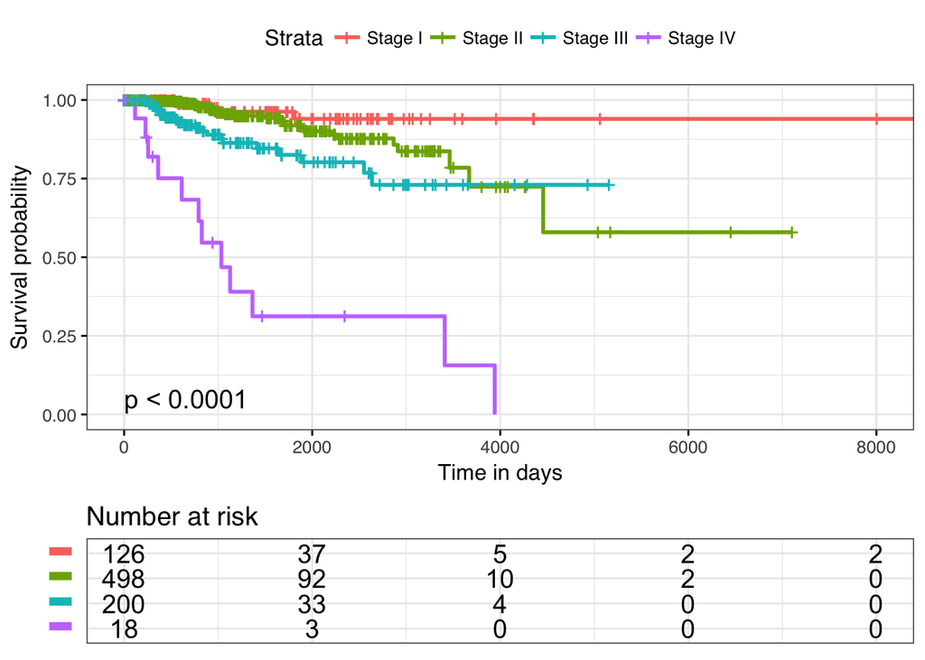

```r
fit <- survfit(Surv(time, ind) ~ ajcc_pathologic_tumor_stage, #modify the variables in the model
               data = cancerType)

ggsurvplot(fit, data = cancerType,
                tables.y.text = FALSE,
                tables.theme = theme_cleantable(),
                xlab = "Time in days",
                pval = T,
                pval.coord = c(0.05, 0.05),
                legend.labs = c("Stage I", "Stage II", "Stage III", "Stage IV"),
                risk.table = TRUE,
                fontsize = 5,
                ggtheme = theme_bw(base_family = "sans", base_size = 12))
```

### Multivariate Analysis of clinical variables

```r
MVmodel <- coxph(Surv(time, ind) ~subtype+ajcc_pathologic_tumor_stage+histological_type, data=cancerType)
summary(MVmodel)
```

```
## Call:
## coxph(formula = Surv(time, ind) ~ subtype + ajcc_pathologic_tumor_stage +
##     histological_type, data = cancerType)
##
##   n= 657, number of events= 53
##    (216 observations deleted due to missingness)
##
##                                              coef  exp(coef)   se(coef)
## subtypeHer2                             1.333e-01  1.143e+00  4.953e-01
## subtypeLumA                            -5.177e-01  5.959e-01  4.059e-01
## subtypeLumB                            -2.755e-01  7.592e-01  4.298e-01
## subtypeNormal                          -1.744e+01  2.654e-08  4.354e+03
## ajcc_pathologic_tumor_stageStage II     6.383e-01  1.893e+00  5.476e-01
## ajcc_pathologic_tumor_stageStage III    1.493e+00  4.450e+00  5.704e-01
## ajcc_pathologic_tumor_stageStage IV     3.143e+00  2.317e+01  6.142e-01
## histological_typeILC                    1.261e-02  1.013e+00  5.621e-01
## histological_typeMedullary Carcinoma   -1.707e+01  3.852e-08  6.431e+03
## histological_typeMetaplastic Carcinoma -1.672e+01  5.461e-08  1.714e+04
## histological_typeMixed Histology       -9.061e-01  4.041e-01  1.044e+00
## histological_typeMucinous Carcinoma     1.392e+00  4.022e+00  1.037e+00
## histological_typeOther                  6.742e-01  1.963e+00  5.335e-01
##                                             z Pr(>|z|)
## subtypeHer2                             0.269  0.78785
## subtypeLumA                            -1.275  0.20217
## subtypeLumB                            -0.641  0.52157
## subtypeNormal                          -0.004  0.99680
## ajcc_pathologic_tumor_stageStage II     1.165  0.24382
## ajcc_pathologic_tumor_stageStage III    2.617  0.00887 **
## ajcc_pathologic_tumor_stageStage IV     5.117 3.11e-07 ***
## histological_typeILC                    0.022  0.98210
## histological_typeMedullary Carcinoma   -0.003  0.99788
## histological_typeMetaplastic Carcinoma -0.001  0.99922
## histological_typeMixed Histology       -0.868  0.38564
## histological_typeMucinous Carcinoma     1.343  0.17942
## histological_typeOther                  1.264  0.20633
## ---
## Signif. codes:  0 '***' 0.001 '**' 0.01 '*' 0.05 '.' 0.1 ' ' 1
##
##                                        exp(coef) exp(-coef) lower .95
## subtypeHer2                            1.143e+00  8.752e-01   0.43281
```

[output cut: 17 more lines]

```
## ajcc_pathologic_tumor_stageStage II        5.538
## ajcc_pathologic_tumor_stageStage III      13.611
## ajcc_pathologic_tumor_stageStage IV       77.207
## histological_typeILC                       3.047
## histological_typeMedullary Carcinoma         Inf
## histological_typeMetaplastic Carcinoma       Inf
## histological_typeMixed Histology           3.130
## histological_typeMucinous Carcinoma       30.671
## histological_typeOther                     5.584
##
## Concordance= 0.764  (se = 0.045 )
## Rsquare= 0.07   (max possible= 0.584 )
## Likelihood ratio test= 47.89  on 13 df,   p=7e-06
## Wald test            = 52.63  on 13 df,   p=1e-06
## Score (logrank) test = 85.9  on 13 df,   p=8e-13
```

Another way to visualize the aareg function - Aalen additive regression model (aareg). More information can be found at the [function information.](https://stat.ethz.ch/R-manual/R-devel/library/survival/html/aareg.html). We will input the same variables we are interested in using a similar equation to the coxph model. The function and subsequent autoplotting of aareg shows the how the effect of the covariate changes over time.

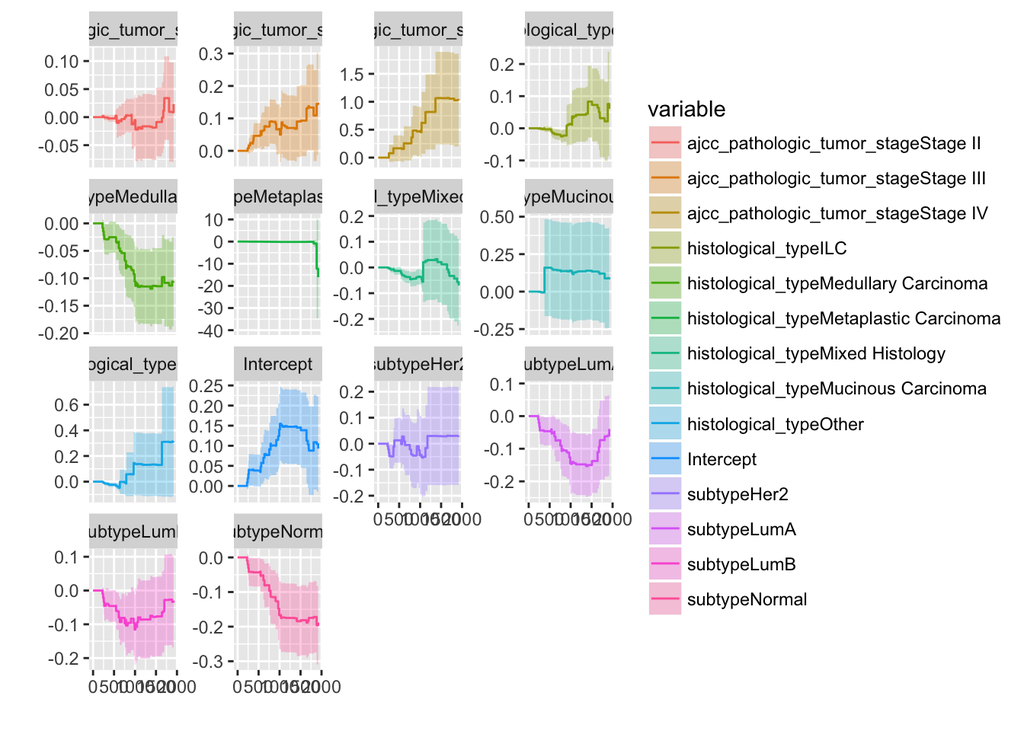

```r
aa_fit <-aareg(Surv(time, ind) ~ subtype+ajcc_pathologic_tumor_stage+histological_type ,
                 data = cancerType)
autoplot(aa_fit)
```

```r
summary(aa_fit)
```

```
## $table
##                                                slope          coef
## Intercept                               1.565276e-04  0.0032198484
## subtypeHer2                            -1.706117e-05  0.0001831700
## subtypeLumA                            -1.649604e-04 -0.0027249149
## subtypeLumB                            -1.420391e-04 -0.0022242866
## subtypeNormal                          -1.859389e-04 -0.0046890511
## ajcc_pathologic_tumor_stageStage II    -7.553469e-06  0.0001340192
## ajcc_pathologic_tumor_stageStage III    1.329009e-04  0.0033332105
## ajcc_pathologic_tumor_stageStage IV     9.839442e-04  0.0233310143
## histological_typeILC                    1.882594e-05  0.0009550691
## histological_typeMedullary Carcinoma   -9.252856e-05 -0.0026414294
## histological_typeMetaplastic Carcinoma -1.172894e-04 -0.0022424477
## histological_typeMixed Histology       -2.996794e-05 -0.0006814547
## histological_typeMucinous Carcinoma     4.291355e-04  0.0060077586
## histological_typeOther                  1.138147e-04  0.0036755856
##                                            se(coef)           z
## Intercept                              0.0013383808  2.40577898
## subtypeHer2                            0.0023843368  0.07682219
## subtypeLumA                            0.0014198873 -1.91910643
## subtypeLumB                            0.0015841362 -1.40410063
## subtypeNormal                          0.0013416989 -3.49486099
## ajcc_pathologic_tumor_stageStage II    0.0008370694  0.16010522
## ajcc_pathologic_tumor_stageStage III   0.0014834974  2.24685960
## ajcc_pathologic_tumor_stageStage IV    0.0087605984  2.66317587
## histological_typeILC                   0.0012357226  0.77288307
## histological_typeMedullary Carcinoma   0.0009614836 -2.74724323
## histological_typeMetaplastic Carcinoma 0.0014046513 -1.59644446
## histological_typeMixed Histology       0.0018408689 -0.37018102
## histological_typeMucinous Carcinoma    0.0072400973  0.82978976
## histological_typeOther                 0.0030642951  1.19948813
##                                                   p
## Intercept                              0.0161380247
## subtypeHer2                            0.9387649953
## subtypeLumA                            0.0549708654
## subtypeLumB                            0.1602888864
## subtypeNormal                          0.0004743087
## ajcc_pathologic_tumor_stageStage II    0.8727981880
## ajcc_pathologic_tumor_stageStage III   0.0246490015
## ajcc_pathologic_tumor_stageStage IV    0.0077406946
```

[output cut: 84 more lines]

```
##     0.0017985089 -0.0027630140  9.374733e-01  0.008285669
##     0.0222048847 -0.0475855639  8.285669e-03  3.437252002
##
## $test.var2
## NULL
##
## $chisq
##          [,1]
## [1,] 39.97499
##
## $n
## [1] 657  42  52
##
## attr(,"class")
## [1] "summary.aareg"
```

# Analysis using protein-level data from RPPA

Clinical variables are more straight forward when it comes to multivariate analysis, they are categorical. RPPA values available in the TRGAted application are continuous and transformed using z-scores. To begin, we will need to identify the protein or proteins of interest, select a cut-off, and convert them to categorical variables. We are going to select proteins that are tested via immunohistochemistry as part of a standard work-up for breast cancer diagnosis and treatment.

```r
time = "DSS.time" #diseas-specific survival
ind = "DSS"
proteins <- c("ERALPHA", "PR", "HER2")

cut <- surv_cutpoint(cancerType, time=time, event=ind, variables=proteins)
cat <- surv_categorize(cut)
rownames(cat) <- cancerType$patient
cat[1:10,1:5]
```

```
##              DSS.time DSS ERALPHA   PR HER2
## TCGA-3C-AALI     4005   0     low high high
## TCGA-3C-AALK     1448   0     low high high
## TCGA-4H-AAAK      348   0    high high high
## TCGA-5L-AAT1     1471   0    high high high
## TCGA-5T-A9QA      303   0    high high high
## TCGA-A1-A0SF     1463   0    high high high
## TCGA-A1-A0SH     1437   0     low high high
## TCGA-A1-A0SJ      416   0     low high high
## TCGA-A1-A0SK      967   1     low  low  low
## TCGA-A1-A0SO      852   0     low  low high
```

We now have the samples categorized into high or low groupings for each protein. We next need to add our other clinical variables of interest.

```r
cat <- cbind.data.frame(cat, cancerType$subtype, cancerType$ajcc_pathologic_tumor_stage, cancerType$histological_type)
colnames(cat)[6] <- "subtype"
colnames(cat)[7] <- "tumor_stage"
colnames(cat)[8] <- "histological_type"
```

Now we can update our equation from above to include our new data frame, cat, with both our proteins and clinical variables of interest.

```r
MVmodel2 <- coxph(Surv(DSS.time, DSS) ~ERALPHA+PR+HER2+subtype+tumor_stage+histological_type, data=cat)
summary(MVmodel2)
```

```
## Call:
## coxph(formula = Surv(DSS.time, DSS) ~ ERALPHA + PR + HER2 + subtype +
##     tumor_stage + histological_type, data = cat)
##
##   n= 657, number of events= 53
##    (216 observations deleted due to missingness)
##
##                                              coef  exp(coef)   se(coef)
## ERALPHAlow                              5.173e-01  1.678e+00  3.449e-01
## PRlow                                   8.896e-01  2.434e+00  3.455e-01
## HER2low                                -4.511e-01  6.369e-01  3.540e-01
## subtypeHer2                             5.143e-03  1.005e+00  5.217e-01
## subtypeLumA                             1.026e-01  1.108e+00  4.817e-01
## subtypeLumB                             3.233e-01  1.382e+00  4.843e-01
## subtypeNormal                          -1.696e+01  4.294e-08  4.471e+03
## tumor_stageStage II                     5.401e-01  1.716e+00  5.512e-01
## tumor_stageStage III                    1.323e+00  3.756e+00  5.752e-01
## tumor_stageStage IV                     3.070e+00  2.155e+01  6.129e-01
## histological_typeILC                    6.959e-02  1.072e+00  5.709e-01
## histological_typeMedullary Carcinoma   -1.729e+01  3.089e-08  6.409e+03
## histological_typeMetaplastic Carcinoma -1.609e+01  1.033e-07  1.786e+04
## histological_typeMixed Histology       -7.916e-01  4.531e-01  1.047e+00
## histological_typeMucinous Carcinoma     1.457e+00  4.293e+00  1.048e+00
## histological_typeOther                  4.967e-01  1.643e+00  5.503e-01
##                                             z Pr(>|z|)
## ERALPHAlow                              1.500   0.1336
## PRlow                                   2.574   0.0100 *
## HER2low                                -1.274   0.2025
## subtypeHer2                             0.010   0.9921
## subtypeLumA                             0.213   0.8313
## subtypeLumB                             0.668   0.5044
## subtypeNormal                          -0.004   0.9970
## tumor_stageStage II                     0.980   0.3272
## tumor_stageStage III                    2.300   0.0214 *
## tumor_stageStage IV                     5.010 5.45e-07 ***
## histological_typeILC                    0.122   0.9030
## histological_typeMedullary Carcinoma   -0.003   0.9978
## histological_typeMetaplastic Carcinoma -0.001   0.9993
## histological_typeMixed Histology       -0.756   0.4496
## histological_typeMucinous Carcinoma     1.390   0.1646
```

[output cut: 29 more lines]

```
## tumor_stageStage II                        5.056
## tumor_stageStage III                      11.596
## tumor_stageStage IV                       71.635
## histological_typeILC                       3.282
## histological_typeMedullary Carcinoma         Inf
## histological_typeMetaplastic Carcinoma       Inf
## histological_typeMixed Histology           3.527
## histological_typeMucinous Carcinoma       33.517
## histological_typeOther                     4.832
##
## Concordance= 0.791  (se = 0.046 )
## Rsquare= 0.086   (max possible= 0.584 )
## Likelihood ratio test= 58.83  on 16 df,   p=8e-07
## Wald test            = 67.98  on 16 df,   p=2e-08
## Score (logrank) test = 101.3  on 16 df,   p=2e-14
```

# Conclusions

Hopefully this helps users start multivariate analysis using the RPPA datasets embedded in the TRGAted application. Multivariate analysis is complex and prone to a number of biases, if you are in doubt with how to perform an analysis or assess which model is superior, we suggest you consult a statistician at your institution. If you have anymore questions, feel free to email us.